# Week 1 - Homework

STAT 420, Summer 2021, Boshika Tara

05-26-2021

## Exercise 1 (Subsetting and Statistics)

For this exercise, we will use the `msleep` dataset from the `ggplot2` package.

**(a)** Install and load the `ggplot2` package. **Do not** include the installation command in your `.Rmd` file. (If you do it will install the package every time you knit your file.) **Do** include the command to load the package into your environment.

```r
library(ggplot2)
```

**(b)** Note that this dataset is technically a `tibble`, not a data frame. How many observations are in this dataset? How many variables? What are the observations in this dataset?

```r
data <- msleep
obs <- summary(data)
obs
```

```
##      name              genus               vore              order
##  Length:83          Length:83          Length:83          Length:83
##  Class :character   Class :character   Class :character   Class :character
##  Mode  :character   Mode  :character   Mode  :character   Mode  :character
##
##
##
##
##  conservation        sleep_total      sleep_rem      sleep_cycle
##  Length:83          Min.   : 1.90   Min.   :0.100   Min.   :0.1167
##  Class :character   1st Qu.: 7.85   1st Qu.:0.900   1st Qu.:0.1833
##  Mode  :character   Median :10.10   Median :1.500   Median :0.3333
##                     Mean   :10.43   Mean   :1.875   Mean   :0.4396
##                     3rd Qu.:13.75   3rd Qu.:2.400   3rd Qu.:0.5792
##                     Max.   :19.90   Max.   :6.600   Max.   :1.5000
##                                     NA's   :22      NA's   :51
##      awake          brainwt            bodywt
##  Min.   : 4.10   Min.   :0.00014   Min.   :   0.005
##  1st Qu.:10.25   1st Qu.:0.00290   1st Qu.:   0.174
##  Median :13.90   Median :0.01240   Median :   1.670
##  Mean   :13.57   Mean   :0.28158   Mean   : 166.136
##  3rd Qu.:16.15   3rd Qu.:0.12550   3rd Qu.:  41.750
##  Max.   :22.10   Max.   :5.71200   Max.   :6654.000
##                  NA's   :27
```

```r
cat("No of observations: ", nrow(data), '\n')
```

```
## No of observations:  83
```

```r
cat("No of variables: ", ncol(data))
```

```
## No of variables:  11
```

**(c)** What is the mean hours of REM sleep of individuals in this dataset?

```r
mean_rem_sleep <- mean(data$sleep_rem, na.rm=TRUE)
cat("Mean hours of REM sleep of individuals: ", mean_rem_sleep)
```

```
## Mean hours of REM sleep of individuals:  1.87541
```

**(d)** What is the standard deviation of brain weight of individuals in this dataset?

```r
sd_brain_weight <- sd(data$brainwt, na.rm=TRUE)
cat("Standard deviation of brain weight of individuals: ", sd_brain_weight)
```

```
## Standard deviation of brain weight of individuals:  0.9764137
```

**(e)** Which observation (provide the `name`) in this dataset gets the most REM sleep?

```r
max_rem_sleep <- data$name[which.max(data$sleep_rem)]
cat("Observation with the most REM sleep: ", max_rem_sleep)
```

```
## Observation with the most REM sleep:  Thick-tailed opposum
```

**(f)** What is the average bodyweight of carnivores in this dataset?

```r
avg_body_weight <- mean(data$bodywt[data$vore=='carni'], na.rm = TRUE)
cat("Average bodyweight of carnivores: ", avg_body_weight)
```

```
## Average bodyweight of carnivores:  90.75111
```

## Exercise 2 (Plotting)

For this exercise, we will use the `birthwt` dataset from the `MASS` package.

**(a)** Note that this dataset is a data frame and all of the variables are numeric. How many observations are in this dataset? How many variables? What are the observations in this dataset?

```r
library(MASS)
library(tidyverse)
birthwt.df <- MASS::birthwt
birthwt <- as_tibble(birthwt.df)
birthwt <- birthwt %>%
 mutate(race = recode_factor(race, `1` = "white", `2` = "black", `3` = "other"))
birthwt <- birthwt %>%
 mutate(smoke = recode_factor(smoke, `0` = "NO", `1` = "YES"))
observations <- summary(birthwt)
observations
```

```
##       low              age             lwt           race    smoke
##  Min.   :0.0000   Min.   :14.00   Min.   : 80.0   white:96   NO :115
##  1st Qu.:0.0000   1st Qu.:19.00   1st Qu.:110.0   black:26   YES: 74
##  Median :0.0000   Median :23.00   Median :121.0   other:67
##  Mean   :0.3122   Mean   :23.24   Mean   :129.8
##  3rd Qu.:1.0000   3rd Qu.:26.00   3rd Qu.:140.0
##  Max.   :1.0000   Max.   :45.00   Max.   :250.0
##       ptl               ht                ui              ftv
##  Min.   :0.0000   Min.   :0.00000   Min.   :0.0000   Min.   :0.0000
##  1st Qu.:0.0000   1st Qu.:0.00000   1st Qu.:0.0000   1st Qu.:0.0000
##  Median :0.0000   Median :0.00000   Median :0.0000   Median :0.0000
##  Mean   :0.1958   Mean   :0.06349   Mean   :0.1481   Mean   :0.7937
##  3rd Qu.:0.0000   3rd Qu.:0.00000   3rd Qu.:0.0000   3rd Qu.:1.0000
##  Max.   :3.0000   Max.   :1.00000   Max.   :1.0000   Max.   :6.0000
##       bwt
##  Min.   : 709
##  1st Qu.:2414
##  Median :2977
##  Mean   :2945
##  3rd Qu.:3487
##  Max.   :4990
```

```r
cat("No of observations: ", nrow(birthwt), '\n')
```

```
## No of observations:  189
```

```r
cat("No of variables: ", ncol(birthwt))
```

```
## No of variables:  10
```

```r
tbl.mean.bwt <- birthwt %>%
  group_by(race, smoke) %>%
  summarize(mean.birthwt = round(mean(bwt), 0))
knitr::kable(tbl.mean.bwt)
```

| race | smoke | mean.birthwt |
| --- | --- | --- |
| white | NO | 3429 |
| white | YES | 2827 |
| black | NO | 2854 |
| black | YES | 2504 |
| other | NO | 2816 |
| other | YES | 2757 |

**(b)** Create a scatter plot of birth weight (y-axis) vs mother’s weight before pregnancy (x-axis). Use a non-default color for the points. (Also, be sure to give the plot a title and label the axes appropriately.) Based on the scatter plot, does there seem to be a relationship between the two variables? Briefly explain.

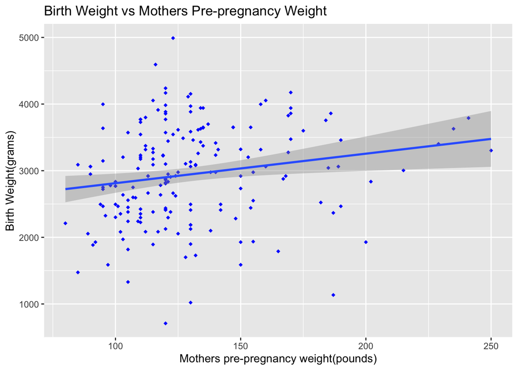

```r
ggplot(birthwt, aes(x=lwt, y=bwt)) +
  ylab("Birth Weight(grams)") +
  xlab("Mothers pre-pregnancy weight(pounds)") +
  ggtitle("Birth Weight vs Mothers Pre-pregnancy Weight") +
  geom_point(shape=18, color="blue") +
  geom_smooth(method=lm)
```

**Observation** The plot above shows little to no correlation between mother’s pre-pregnancy weight ad birth weights, especially for pre-pregnancy weights between 100-150 pounds, it does look like as the weight increases(>150 pounds) birth weights increase, but the data for that range is not enough to really make that prediction.

**(c)** Create a scatter plot of birth weight (y-axis) vs mother’s age (x-axis). Use a non-default color for the points. (Also, be sure to give the plot a title and label the axes appropriately.) Based on the scatter plot, does there seem to be a relationship between the two variables? Briefly explain.

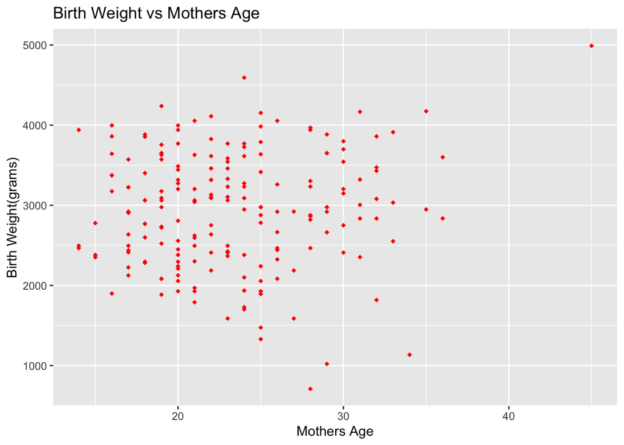

```r
ggplot(birthwt, aes(x=age, y=bwt)) +
  ylab("Birth Weight(grams)") +
  xlab("Mothers Age") +
  ggtitle("Birth Weight vs Mothers Age") +
  geom_point(shape=18, color="red")
```

**(d)** Create side-by-side boxplots for birth weight grouped by smoking status. Use non-default colors for the plot. (Also, be sure to give the plot a title and label the axes appropriately.) Based on the boxplot, does there seem to be a difference in birth weight for mothers who smoked? Briefly explain.

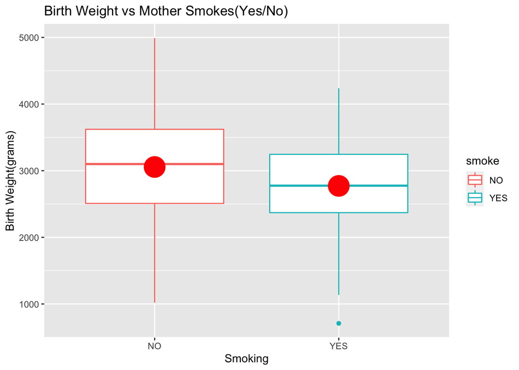

```r
p<-ggplot(birthwt, aes(x=smoke, y=bwt, color=smoke)) +
  ylab("Birth Weight(grams)") +
  xlab("Smoking") +
  ggtitle("Birth Weight vs Mother Smokes(Yes/No)") +
  geom_boxplot() +
  stat_summary(fun=mean, geom="point", shape=20, size=14, color="red", fill="red")
p
```

**Observation** There seems to be a correlation between mother’s smoking and birth weights, it seems that mothers who smoke have lower birth weights, compared to women who do not smoke. ***

## Exercise 3 (Importing Data, More Plotting)

For this exercise we will use the data stored in `nutrition-2018.csv`. It contains the nutritional values per serving size for a large variety of foods as calculated by the USDA in 2018. It is a cleaned version totaling 5956 observations and is current as of April 2018.

The variables in the dataset are:

- `ID`
- `Desc` - short description of food
- `Water` - in grams
- `Calories` - in kcal
- `Protein` - in grams
- `Fat` - in grams
- `Carbs` - carbohydrates, in grams
- `Fiber` - in grams
- `Sugar` - in grams
- `Calcium` - in milligrams
- `Potassium` - in milligrams
- `Sodium` - in milligrams
- `VitaminC` - vitamin C, in milligrams
- `Chol` - cholesterol, in milligrams
- `Portion` - description of standard serving size used in analysis

```r
nutrition <- read.csv("nutrition-2018.csv")
```

**(a)** Create a histogram of `Calories`. Do not modify `R`’s default bin selection. Make the plot presentable. Describe the shape of the histogram. Do you notice anything unusual?

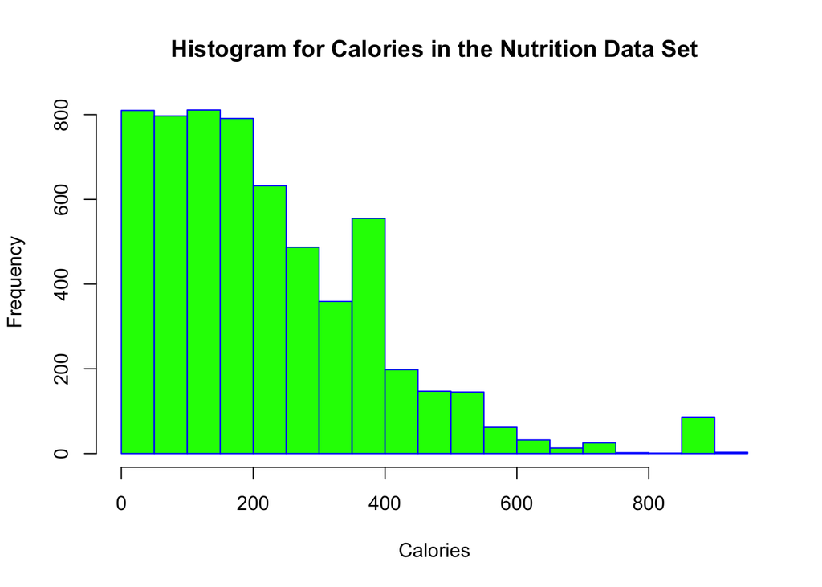

```r
hist(nutrition$Calories,
     main="Histogram for Calories in the Nutrition Data Set",
     xlab="Calories",
     border="blue",
     col="green",
     )
```

**(b)** Create a scatter plot of calories (y-axis) vs protein (x-axis). Make the plot presentable. Do you notice any trends? Do you think that knowing only the protein content of a food, you could make a good prediction of the calories in the food?

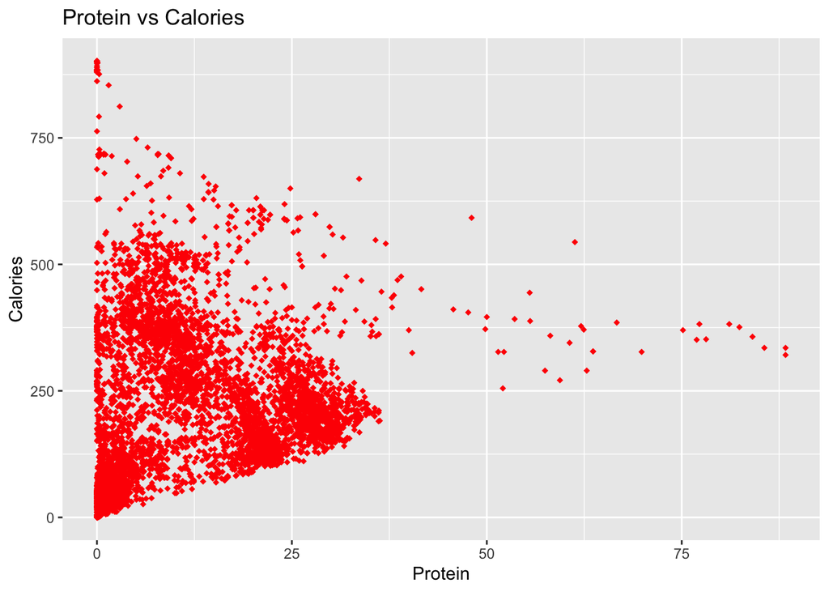

```r
ggplot(nutrition, aes(x=Protein, y=Calories)) +
  ylab("Calories") +
  xlab("Protein") +
  ggtitle("Protein vs Calories") +
  geom_point(shape=18, color="red")
```

**Observation** It seems that Protein in the range of 0-30, is associated with Calories between 0-500.

**(c)** Create a scatter plot of `Calories` (y-axis) vs `4 * Protein + 4 * Carbs + 9 * Fat` (x-axis). Make the plot presentable. You will either need to add a new variable to the data frame, or use the `I()` function in your formula in the call to `plot()`. If you are at all familiar with nutrition, you may realize that this formula calculates the calorie count based on the protein, carbohydrate, and fat values. You’d expect then that the result here is a straight line. Is it? If not, can you think of any reasons why it is not?

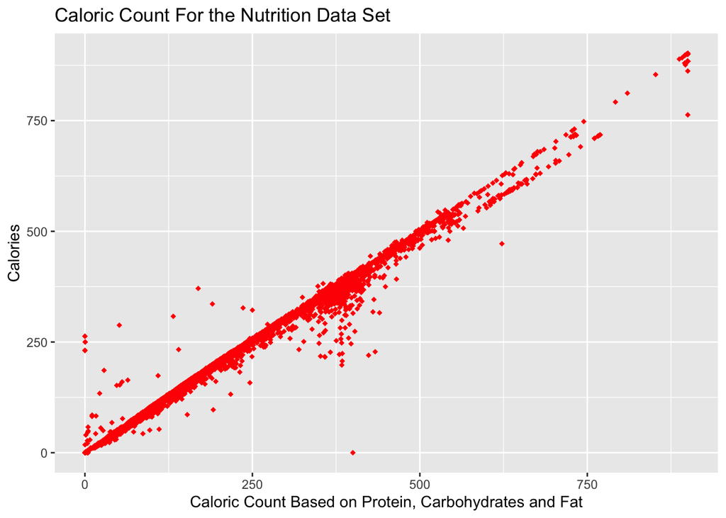

```r
nutrition$Aggregate =  4 * nutrition$Protein + 4 * nutrition$Carbs + 9 * nutrition$Fat
ggplot(nutrition, aes(x=Aggregate, y=Calories)) +
  ylab("Calories") +
  xlab("Caloric Count Based on Protein, Carbohydrates and Fat") +
  ggtitle("Caloric Count For the Nutrition Data Set") +
  geom_point(shape=18, color="red")
```

## Exercise 4 (Writing and Using Functions)

For each of the following parts, use the following vectors:

```r
a = 1:10
b = 10:1
c = rep(1, times = 10)
d = 2 ^ (1:10)
```

**(a)** Write a function called `sum_of_squares`.

- Arguments:
  - A vector of numeric data `x`
- Output:
  - The sum of the squares of the elements of the vector $\sum_{i = 1}^n x_i^2$

Provide your function, as well as the result of running the following code:

```r
sum_of_squares <- function(x) {
   sum_of_sq <- sum(x^2)

   return(sum_of_sq)
}
sum_of_squares(x = a)
```

```
## [1] 385
```

```r
sum_of_squares(x = c(c, d))
```

```
## [1] 1398110
```

**(b)** Using only your function `sum_of_squares()`, `mean()`, `sqrt()`, and basic math operations such as `+` and `-`, calculate

$$\sqrt{\frac{1}{n}\sum_{i = 1}^n (x_i - 0)^{2}}$$

where the $x$ vector is `d`.

```r
sq <- function(y){
  x=y/2
  while (abs(x*x-y) > 1e-10)
  {x=(x+y/x)/2 }
  x
}

avg <- function(v, i){
  m <- sum_of_squares(v) - sum_of_squares(i)
  return(m * 1/length(v))
}

calculate_sum_of_squares <- avg(d, 0)
ans <- sq(calculate_sum_of_squares)
ans
```

```
## [1] 373.9118
```

**(c)** Using only your function `sum_of_squares()`, `mean()`, `sqrt()`, and basic math operations such as `+` and `-`, calculate

$$\sqrt{\frac{1}{n}\sum_{i = 1}^n (x_i - y_i)^{2}}$$

where the $x$ vector is `a` and the $y$ vector is `b`.

```r
calculate_sum_of_squares_a_b <- avg(a, b)
calculate_sum_of_squares_a_b
```

```
## [1] 0
```

```r
ans_a_b <- sq(calculate_sum_of_squares_a_b)
ans_a_b
```

```
## [1] 0
```

## Exercise 5 (More Writing and Using Functions)

For each of the following parts, use the following vectors:

```r
set.seed(42)
x = 1:100
y = rnorm(1000)
z = runif(150, min = 0, max = 1)
```

**(a)** Write a function called `list_extreme_values`.

- Arguments:
  - A vector of numeric data `x`
  - A positive constant, `k`, with a default value of `2`
- Output:
  - A list with two elements:
    - `small`, a vector of elements of `x` that are $k$ sample standard deviations less than the sample mean. That is, the observations that are smaller than $\bar{x} - k \cdot s$.
    - `large`, a vector of elements of `x` that are $k$ sample standard deviations greater than the sample mean. That is, the observations that are larger than $\bar{x} + k \cdot s$.

Provide your function, as well as the result of running the following code:

```r
list_extreme_values <- function(x, k = 2) {
  sample_mean = sum(x)/length(x)
  small_sd <- sample_mean - k * sd(x)
  large_sd <- sample_mean + k * sd(x)


  small <- x[x < small_sd]

  large <- x[x > large_sd]

  return (c(small, large))
}

list_extreme_values(x = x, k = 1)
```

```
##  [1]   1   2   3   4   5   6   7   8   9  10  11  12  13  14  15  16  17  18  19
## [20]  20  21  80  81  82  83  84  85  86  87  88  89  90  91  92  93  94  95  96
## [39]  97  98  99 100
```

```r
list_extreme_values(x = y, k = 3)
```

```
## [1] -3.371739  3.229069  3.211199  3.495304
```

```r
list_extreme_values(x = y, k = 2)
```

```
##  [1] -2.656455 -2.440467 -2.414208 -2.993090 -2.699930 -2.113200 -2.188835
##  [8] -2.071388 -2.138368 -2.461335 -2.170247 -3.017933 -2.192786 -2.253132
## [15] -2.277778 -2.292971 -2.206485 -2.553825 -2.082814 -2.958780 -2.136025
## [22] -2.183149 -3.371739  2.018424  2.286645  2.701891  2.059539  2.036972
## [29]  2.049961  2.459594  2.212055  2.422163  2.019891  2.965865  2.098031
## [36]  2.241904  2.041313  3.229069  2.223534  3.211199  2.623495  2.727196
## [43]  2.178668  3.495304
```

```r
list_extreme_values(x = z, k = 1.5)
```

```
##  [1] 0.001703130 0.077464589 0.047054933 0.060877148 0.009629518 0.004321658
##  [7] 0.028495955 0.005327612 0.041129370 0.989965585 0.952181471 0.974126069
## [13] 0.947400911 0.958697934 0.975643595 0.995456439 0.951732153 0.934264273
## [19] 0.931007524
```

**(b)** Using only your function `list_extreme_values()`, `mean()`, and basic list operations, calculate the mean of observations that are greater than 1.5 standard deviation above the mean in the vector `y`.

```r
y_list_of_extreme_values <- list_extreme_values(y)
mean_y <- sum(y)/length(y)
sd_y <- 1.5 * sd(y)
y_list_of_extreme_values_above_sd <-  y_list_of_extreme_values[y_list_of_extreme_values > sd_y]
y_list_of_extreme_values_above_sd
```

```
##  [1] 2.018424 2.286645 2.701891 2.059539 2.036972 2.049961 2.459594 2.212055
##  [9] 2.422163 2.019891 2.965865 2.098031 2.241904 2.041313 3.229069 2.223534
## [17] 3.211199 2.623495 2.727196 2.178668 3.495304
```

## References

- https://www.andrew.cmu.edu/user/achoulde/94842/lectures/lecture05/lecture05-94842.html
- https://www.rdocumentation.org/packages/dplyr/versions/0.7.8
- https://rpubs.com/Lopamudra_Satpathy/374930
- http://www.sthda.com/english/wiki/ggplot2-scatter-plots-quick-start-guide-r-software-and-data-visualization
- https://stackoverflow.com/questions/40711241/writing-a-square-root-function-in-r